# Densenet_V1

## Import Packages

```python
from IPython.core.display import display, HTML
display(HTML('<style>.container { width:100% !important; }</style>'))
```

```python
# # Install packages
!pip install pydicom
```

```
     |████████████████████████████████| 35.5MB 89kB/s
```

```python
from google.colab import drive
drive.mount('/content/drive')
```

```python
# IMPORT PACKAGES
import warnings; warnings.filterwarnings('ignore')
import pandas as pd, numpy as np
import matplotlib.pyplot as plt
from tqdm import tqdm_notebook
import os, zipfile, random, csv
import seaborn as sns
import pydicom as dcm
from glob import glob
import cv2

%matplotlib inline

# SET VARIABLES
PATH = '/content/drive/My Drive/Final_Project/'
os.chdir(PATH)

DATA_DIR = os.path.join(PATH + 'data/')
TRAIN_IMAGES = os.path.join(DATA_DIR + 'stage_2_train_images/')
TEST_IMAGES = os.path.join(DATA_DIR + 'stage_2_test_images/')
OUTPUT_DIR = os.path.join(PATH + 'output/')

if not os.path.exists(DATA_DIR): os.makedirs(DATA_DIR)
# if not os.path.exists(TRAIN_IMAGES): os.makedirs(TRAIN_IMAGES)
# if not os.path.exists(TEST_IMAGES): os.makedirs(TEST_IMAGES)
if not os.path.exists(OUTPUT_DIR): os.makedirs(OUTPUT_DIR)
os.environ['KAGGLE_CONFIG_DIR'] = DATA_DIR

# #CUSTOM MODULES
from module.eda import *
# from module.visualize import *

# #SET RANDOM SEED
np.random.seed(2018)
```

```python
DATA_DIR
```

```
'/content/drive/My Drive/Final_Project/data/'
```

```python
######################################################
## DOWNLOAD DATASET
## Run this only if you haven't extracted the data yet
######################################################

os.chdir(DATA_DIR)
!pip install --upgrade --force-reinstall --no-deps kaggle
!kaggle competitions download -c rsna-pneumonia-detection-challenge
```

```
     |████████████████████████████████| 61kB 7.2MB/s
  Found existing installation: kaggle 1.5.6
    Uninstalling kaggle-1.5.6:
      Successfully uninstalled kaggle-1.5.6
Downloading rsna-pneumonia-detection-challenge.zip to /content/drive/My Drive/Final_Project/data
100% 3.65G/3.66G [01:49<00:00, 27.3MB/s]
100% 3.66G/3.66G [01:49<00:00, 35.9MB/s]
```

```python
os.chdir(DATA_DIR)
DATA_DIR
```

```
'/content/drive/My Drive/Final_Project/data/'
```

```python
file_name = 'rsna-pneumonia-detection-challenge.zip'
arc = zipfile.ZipFile(file_name, 'r')
arc.extractall()
print(f'Current working directory: {os.getcwd()}')
print('Folder and Files in current directory: {}'.format(os.listdir()))
os.chdir(PATH)
```

```
Current working directory: /content/drive/My Drive/Final_Project/data
Folder and Files in current directory: ['kaggle.json', 'rsna-pneumonia-detection-challenge.zip', 'GCP Credits Request Link - RSNA.txt', 'stage_2_detailed_class_info.csv', 'stage_2_sample_submission.csv', 'stage_2_test_images', 'stage_2_train_images', 'stage_2_train_labels.csv']
```

## Exploratory Data Analysis (EDA)

Here as a part of EDA, we will:

- Start with understanding of the data with a brief on train/test labels and respective class info
- Look at the first five rows of both the csvs (train and test)
- Identify how are classes and target distributed
- Check the number of patients with 1, 2, ... bounding boxes
- Read and extract metadata from dicom files
- Perform analysis on some of the features from dicom files
- Check some random images from the training dataset
- Draw insights from the data at various stages of EDA

### Reading CSVs

- Images for the current stage in the `stage_2_train_images` and `stage_2_test_images`.
- Training data: `stage_2_train_labels.csv`
- `stage_2_detailed_class_info.csv` containing detailed information about the positive and negative classes in the training set

```python
print('--'*15, 'Reading Datasets (two csv files)', '--'*15)
train_labels = pd.read_csv(DATA_DIR + 'stage_2_train_labels.csv')
class_info = pd.read_csv(DATA_DIR +'stage_2_detailed_class_info.csv')

print(f'Train Labels dataframe has {train_labels.shape[0]} rows and {train_labels.shape[1]} columns')
print(f'Class info dataframe has {class_info.shape[0]} rows and {class_info.shape[1]} columns')
print('Number of duplicates in patientID in train labels dataframe: {}'.format(len(train_labels) - (train_labels['patientId'].nunique())))
print('Number of duplicates in patientID in class info dataframe: {}'.format(len(class_info) - (class_info['patientId'].nunique())))
```

```
------------------------------ Reading Datasets (two csv files) ------------------------------
Train Labels dataframe has 30227 rows and 6 columns
Class info dataframe has 30227 rows and 2 columns
Number of duplicates in patientID in train labels dataframe: 3543
Number of duplicates in patientID in class info dataframe: 3543
```

```python
print('--'*10, 'First five rows of both dataframes (train_labels, class_info)', '--'*10)
print('Train labels dataframe:\n'); display(train_labels.head())
print('\nClass info dataframe:\n'); display(class_info.head())
```

```
-------------------- First five rows of both dataframes (train_labels, class_info) --------------------
Train labels dataframe:
```

|  | patientId | x | y | width | height | Target |
| --- | --- | --- | --- | --- | --- | --- |
| 0 | 0004cfab-14fd-4e49-80ba-63a80b6bddd6 | NaN | NaN | NaN | NaN | 0 |
| 1 | 00313ee0-9eaa-42f4-b0ab-c148ed3241cd | NaN | NaN | NaN | NaN | 0 |
| 2 | 00322d4d-1c29-4943-afc9-b6754be640eb | NaN | NaN | NaN | NaN | 0 |
| 3 | 003d8fa0-6bf1-40ed-b54c-ac657f8495c5 | NaN | NaN | NaN | NaN | 0 |
| 4 | 00436515-870c-4b36-a041-de91049b9ab4 | 264.0 | 152.0 | 213.0 | 379.0 | 1 |

```
Class info dataframe:
```

|  | patientId | class |
| --- | --- | --- |
| 0 | 0004cfab-14fd-4e49-80ba-63a80b6bddd6 | No Lung Opacity / Not Normal |
| 1 | 00313ee0-9eaa-42f4-b0ab-c148ed3241cd | No Lung Opacity / Not Normal |
| 2 | 00322d4d-1c29-4943-afc9-b6754be640eb | No Lung Opacity / Not Normal |
| 3 | 003d8fa0-6bf1-40ed-b54c-ac657f8495c5 | Normal |
| 4 | 00436515-870c-4b36-a041-de91049b9ab4 | Lung Opacity |

```python
print('Numbers of nulls in bounding boxes columns are equal to the 0s we\'ve in Target column'); print('--'*40)
print('Checking nulls in bounding boxes columns: {}'.format(train_labels[['x', 'y', 'width', 'height']].isnull().sum().to_dict()))
print('Checking value counts for the targets: {}'.format(train_labels['Target'].value_counts().to_dict()))
```

```
Numbers of nulls in bounding boxes columns are equal to the 0s we've in Target column
--------------------------------------------------------------------------------
Checking nulls in bounding boxes columns: {'x': 20672, 'y': 20672, 'width': 20672, 'height': 20672}
Checking value counts for the targets: {0: 20672, 1: 9555}
```

```
Lets check the distribution of `Target` and `class` column
--------------------------------------------------------------------------------
```

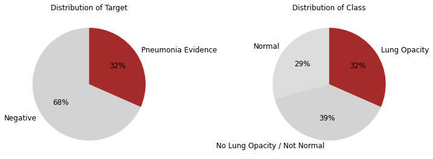

```python
print('Lets check the distribution of `Target` and `class` column'); print('--'*40)
fig = plt.figure(figsize = (10, 6))
ax = fig.add_subplot(121)
g = (train_labels['Target'].value_counts()
    .plot(kind = 'pie', autopct = '%.0f%%',
          labels = ['Negative', 'Pneumonia Evidence'],
          colors = ['lightgray', 'brown'],
          startangle = 90,
          title = 'Distribution of Target', fontsize = 12)
    .set_ylabel(''))
ax = fig.add_subplot(122)
g = (class_info['class'].value_counts().sort_index(ascending = False)
    .plot(kind = 'pie', autopct = '%.0f%%',
          colors = ['gainsboro', 'lightgray', 'brown'],
          startangle = 90, title = 'Distribution of Class',
          fontsize = 12)
    .set_ylabel(''))
plt.tight_layout()
```

```python
print('Let\'s group by patient IDs and check number of bounding boxes for each unique patient ID');print('--'*40)
bboxes = train_labels.groupby('patientId').size().to_frame('number_of_boxes').reset_index()
train_labels = train_labels.merge(bboxes, on = 'patientId', how = 'left')
print('Number of unique patient IDs in the dataset: {}'.format(len(bboxes)))
print('\nNumber of patientIDs per bboxes in the dataset')
(bboxes.groupby('number_of_boxes')
.size()
.to_frame('number_of_patientIDs_per_boxes')
.reset_index()
.set_index('number_of_boxes')
.sort_values(by = 'number_of_boxes'))
```

```
Let's group by patient IDs and check number of bounding boxes for each unique patient ID
--------------------------------------------------------------------------------
Number of unique patient IDs in the dataset: 26684

Number of patientIDs per bboxes in the dataset
```

| number_of_boxes | number_of_patientIDs_per_boxes |
| --- | --- |
| 1 | 23286 |
| 2 | 3266 |
| 3 | 119 |
| 4 | 13 |

```python
print('Let\'s also check whether each patientId has only one type of class'); print('--'*40)
print('Yes, each patientId is associated with only {} class'.format(class_info.groupby(['patientId'])['class'].nunique().max()))

# Merge the two dataframes
train_class = pd.concat([train_labels, class_info['class']], axis = 1)
print('Shape of the dataset after the merge: {}'.format(train_class.shape))
```

```
Let's also check whether each patientId has only one type of class
--------------------------------------------------------------------------------
Yes, each patientId is associated with only 1 class
Shape of the dataset after the merge: (30227, 8)
```

```python
train_class.head()
```

|  | patientId | x | y | width | height | Target | number_of_boxes | class |
| --- | --- | --- | --- | --- | --- | --- | --- | --- |
| 0 | 0004cfab-14fd-4e49-80ba-63a80b6bddd6 | NaN | NaN | NaN | NaN | 0 | 1 | No Lung Opacity / Not Normal |
| 1 | 00313ee0-9eaa-42f4-b0ab-c148ed3241cd | NaN | NaN | NaN | NaN | 0 | 1 | No Lung Opacity / Not Normal |
| 2 | 00322d4d-1c29-4943-afc9-b6754be640eb | NaN | NaN | NaN | NaN | 0 | 1 | No Lung Opacity / Not Normal |
| 3 | 003d8fa0-6bf1-40ed-b54c-ac657f8495c5 | NaN | NaN | NaN | NaN | 0 | 1 | Normal |
| 4 | 00436515-870c-4b36-a041-de91049b9ab4 | 264.0 | 152.0 | 213.0 | 379.0 | 1 | 2 | Lung Opacity |

#### Observations from the CSVs

Based on analysis above, some of the observations:

- Training data is having a set of patientIds and bounding boxes. Bounding boxes are defined as follows: x, y, width and height.
- There are multiple records for patients. Number of duplicates in patientID = 3,543.
- There is also a binary target column i.e. Target indicating there was evidence of pneumonia or no definitive evidence of pneumonia.
- Class label contains: No Lung Opacity/Not Normal, Normal and Lung Opacity.
- Chest examinations with Target = 1 i.e. ones with evidence of Pneumonia are associated with Lung Opacity class.
- Chest examinations with Target = 0 i.e. those with no definitive effidence of Pneumonia are either of Normal or No Lung Opacity / Not Normal class.
- About 23,286 patientIds (~87% of them) provided have 1 bounding boxes while 13 patients have 4 bounding boxes!!!!

### Reading Images

Images provided are stored in DICOM (.dcm) format which is an international standard to transmit, store, retrieve, print, process, and display medical imaging information. Digital Imaging and Communications in Medicine (DICOM) makes medical imaging information interoperable. We will make use of pydicom package here to read the images.

```python
sample_patient_id = train_labels['patientId'][0]
dcm_file = TRAIN_IMAGES + '{}.dcm'.format(sample_patient_id)
dcm_data = dcm.read_file(dcm_file)

print(dcm_data)
```

```
Dataset.file_meta -------------------------------
(0002, 0000) File Meta Information Group Length  UL: 202
(0002, 0001) File Meta Information Version       OB: b'\x00\x01'
(0002, 0002) Media Storage SOP Class UID         UI: Secondary Capture Image Storage
(0002, 0003) Media Storage SOP Instance UID      UI: 1.2.276.0.7230010.3.1.4.8323329.28530.1517874485.775526
(0002, 0010) Transfer Syntax UID                 UI: JPEG Baseline (Process 1)
(0002, 0012) Implementation Class UID            UI: 1.2.276.0.7230010.3.0.3.6.0
(0002, 0013) Implementation Version Name         SH: 'OFFIS_DCMTK_360'
-------------------------------------------------
(0008, 0005) Specific Character Set              CS: 'ISO_IR 100'
(0008, 0016) SOP Class UID                       UI: Secondary Capture Image Storage
(0008, 0018) SOP Instance UID                    UI: 1.2.276.0.7230010.3.1.4.8323329.28530.1517874485.775526
(0008, 0020) Study Date                          DA: '19010101'
(0008, 0030) Study Time                          TM: '000000.00'
(0008, 0050) Accession Number                    SH: ''
(0008, 0060) Modality                            CS: 'CR'
(0008, 0064) Conversion Type                     CS: 'WSD'
(0008, 0090) Referring Physician's Name          PN: ''
(0008, 103e) Series Description                  LO: 'view: PA'
(0010, 0010) Patient's Name                      PN: '0004cfab-14fd-4e49-80ba-63a80b6bddd6'
(0010, 0020) Patient ID                          LO: '0004cfab-14fd-4e49-80ba-63a80b6bddd6'
(0010, 0030) Patient's Birth Date                DA: ''
(0010, 0040) Patient's Sex                       CS: 'F'
(0010, 1010) Patient's Age                       AS: '51'
(0018, 0015) Body Part Examined                  CS: 'CHEST'
(0018, 5101) View Position                       CS: 'PA'
(0020, 000d) Study Instance UID                  UI: 1.2.276.0.7230010.3.1.2.8323329.28530.1517874485.775525
(0020, 000e) Series Instance UID                 UI: 1.2.276.0.7230010.3.1.3.8323329.28530.1517874485.775524
(0020, 0010) Study ID                            SH: ''
(0020, 0011) Series Number                       IS: "1"
(0020, 0013) Instance Number                     IS: "1"
(0020, 0020) Patient Orientation                 CS: ''
(0028, 0002) Samples per Pixel                   US: 1
(0028, 0004) Photometric Interpretation          CS: 'MONOCHROME2'
(0028, 0010) Rows                                US: 1024
(0028, 0011) Columns                             US: 1024
(0028, 0030) Pixel Spacing                       DS: [0.14300000000000002, 0.14300000000000002]
(0028, 0100) Bits Allocated                      US: 8
(0028, 0101) Bits Stored                         US: 8
(0028, 0102) High Bit                            US: 7
(0028, 0103) Pixel Representation                US: 0
(0028, 2110) Lossy Image Compression             CS: '01'
(0028, 2114) Lossy Image Compression Method      CS: 'ISO_10918_1'
(7fe0, 0010) Pixel Data                          OB: Array of 142006 elements
```

#### Observations from dicom image files

From the above sample we can see that dicom file contains some of the information that can be used for further analysis such as sex, age, body part examined (which should be mostly chest), view position and modality. Size of this image is 1024 x 1024 (rows x columns).

### Feature extraction from the dicom image files

Above we identified some features from the dicom files that can explored/used, let's focus on the following analysis from the image files

- To understand distribution of age for those with evidence of lung opacity and those with no definite evidence of lung opacity.
- To understand distribution of male and female for those with evidence of lung opacity and those with no definite evidence of lung opacity
- Explore different view positions in the dataset
- Explore modallity

To get the features from dicom image files, we will make use of function (`get_tags`) defined in (`eda`).

```python
print('Read the training images file names and path'); print('--'*40)
images = pd.DataFrame({'path': glob(os.path.join(TRAIN_IMAGES, '*.dcm'))})
images['patientId'] = images['path'].map(lambda x: os.path.splitext(os.path.basename(x))[0])
print('Number of images in the training folder: {}'.format(images.shape[0]))
print('Columns in the training images dataframe: {}'.format(list(images.columns)))
assert images.shape[0] == len(list(set(train_class['patientId']))), 'Number of training images should be equal to the unique patientIds we have'
```

```
Read the training images file names and path
--------------------------------------------------------------------------------
Number of images in the training folder: 26684
Columns in the training images dataframe: ['path', 'patientId']
```

```python
print('Merge path from the `images` dataframe with `train_class` dataframe'); print('--'*40)
train_class = train_class.merge(images, on = 'patientId', how = 'left')
print('Shape of the `train_class` dataframe after merge: {}'.format(train_class.shape))
del images
```

```
Merge path from the `images` dataframe with `train_class` dataframe
--------------------------------------------------------------------------------
Shape of the `train_class` dataframe after merge: (30227, 9)
```

```python
print('Get features such as {} from training images'.format(('PatientSex', 'PatientAge', 'BodyPartExamined', 'ViewPosition', 'Modality')))
get_tags(train_class, TRAIN_IMAGES)

print('Saving the feature engineered dataframe for future use'); print('--'*40)
train_class.to_pickle('./output/train_feature_engineered.pkl')
```

```
Get features such as ('PatientSex', 'PatientAge', 'BodyPartExamined', 'ViewPosition', 'Modality') from training images
```

```
Saving the feature engineered dataframe for future use
--------------------------------------------------------------------------------
```

```python
train_class = pd.read_pickle('./output/train_feature_engineered.pkl')
train_class.shape
```

```
(30227, 14)
```

```python
train_class.head()
```

|  | patientId | x | y | width | height | Target | number_of_boxes | class | path | PatientSex | PatientAge | BodyPartExamined | ViewPosition | Modality |
| --- | --- | --- | --- | --- | --- | --- | --- | --- | --- | --- | --- | --- | --- | --- |
| 0 | 0004cfab-14fd-4e49-80ba-63a80b6bddd6 | NaN | NaN | NaN | NaN | 0 | 1 | No Lung Opacity / Not Normal | /content/drive/My Drive/Final_Project/data/sta... | F | 51.0 | CHEST | PA | CR |
| 1 | 00313ee0-9eaa-42f4-b0ab-c148ed3241cd | NaN | NaN | NaN | NaN | 0 | 1 | No Lung Opacity / Not Normal | /content/drive/My Drive/Final_Project/data/sta... | F | 48.0 | CHEST | PA | CR |
| 2 | 00322d4d-1c29-4943-afc9-b6754be640eb | NaN | NaN | NaN | NaN | 0 | 1 | No Lung Opacity / Not Normal | /content/drive/My Drive/Final_Project/data/sta... | M | 19.0 | CHEST | AP | CR |
| 3 | 003d8fa0-6bf1-40ed-b54c-ac657f8495c5 | NaN | NaN | NaN | NaN | 0 | 1 | Normal | /content/drive/My Drive/Final_Project/data/sta... | M | 28.0 | CHEST | PA | CR |
| 4 | 00436515-870c-4b36-a041-de91049b9ab4 | 264.0 | 152.0 | 213.0 | 379.0 | 1 | 2 | Lung Opacity | /content/drive/My Drive/Final_Project/data/sta... | F | 32.0 | CHEST | AP | CR |

```python
print('As expected unique in `BodyPartExamined` is: {}'.format(train_class['BodyPartExamined'].unique()[0]))
print('Unique in `Modality` is: {}'.format(train_class['Modality'].unique()[0])); print('--'*40)
```

```
As expected unique in `BodyPartExamined` is: CHEST
Unique in `Modality` is: CR
--------------------------------------------------------------------------------
```

#### Understanding different View Positions

As seen below, two View Positions that are in the training dataset are AP (Anterior/Posterior) and PA (Posterior/Anterior). These type of X-rays are mostly used to obtain the front-view. Apart from front-view, a lateral image is usually taken to complement the front-view.

- **Posterior/Anterior (PA)**: In PA, X-Ray beam hits the posterior (back) part of the chest before the anterior (front) part. While obtaining the image patient is asked to stand with their chest against the film.
- **Anterior/Posterior (AP)**: Attimes it's not possible for radiographers to acquire a PA chest X-ray. This is usually because the patient is too unwell to stand. AP projection images are of lower quality than PA images. Heart size is exaggerated (cardiothoracic ratio approximately 50%) [[1](https://www.radiologymasterclass.co.uk/tutorials/chest/chest_quality/chest_xray_quality_projection#top_1st_img)].

[figure not shown]

```
Get the distribution of `ViewPosition` overall and where Target = 1
Overall the distribution is almost equal for `ViewPosition` but where there's a Pneumonia Evidence, `ViewPosition` is `AP`
AP: Anterior/Posterior, PA: Posterior/Anterior
--------------------------------------------------------------------------------
```

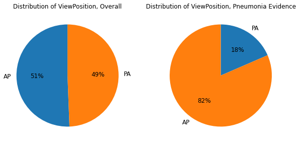

```python
print('Get the distribution of `ViewPosition` overall and where Target = 1')
print('Overall the distribution is almost equal for `ViewPosition` but where there\'s a Pneumonia Evidence, `ViewPosition` is `AP`')
print('AP: Anterior/Posterior, PA: Posterior/Anterior'); print('--'*40)
fig = plt.figure(figsize = (10, 6))
ax = fig.add_subplot(121)
g = (train_class['ViewPosition'].value_counts()
    .plot(kind = 'pie', autopct = '%.0f%%',
          startangle = 90,
          title = 'Distribution of ViewPosition, Overall',
          fontsize = 12)
    .set_ylabel(''))
ax = fig.add_subplot(122)
g = (train_class.loc[train_class['Target'] == 1, 'ViewPosition']
     .value_counts().sort_index(ascending = False)
    .plot(kind = 'pie', autopct = '%.0f%%',
          startangle = 90, counterclock = False,
          title = 'Distribution of ViewPosition, Pneumonia Evidence',
          fontsize = 12)
    .set_ylabel(''))
```

Exploring the bounding boxes for both view positions

- Centers of the rectangle would be x+width/2 and y+height/2 as also described in the reference link [*(source)*](https://stackoverflow.com/questions/32471199/why-is-the-center-of-a-rectangle-xwidth-2-yheight-2-in-java).
- We will make use of (`bboxes_scatter`) function in the (`eda`). Reference for these plots and function [*(source)*](https://www.kaggle.com/gpreda/rsna-pneumonia-detection-eda).

```
Plot x and y centers of bounding boxes
--------------------------------------------------------------------------------
```

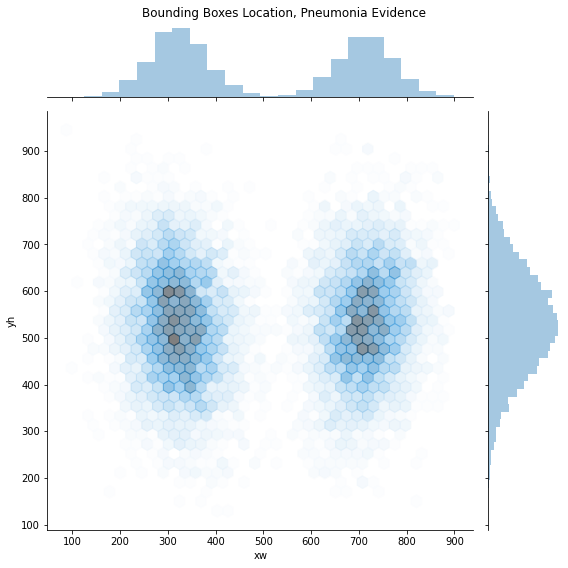

```python
print('Plot x and y centers of bounding boxes'); print('--'*40)
# Creating a dataframe with columns for center of the rectangles
bboxes = train_class[train_class['Target'] == 1]
bboxes['xw'] = bboxes['x'] + bboxes['width'] / 2
bboxes['yh'] = bboxes['y'] + bboxes['height'] / 2

g = sns.jointplot(x = bboxes['xw'], y = bboxes['yh'], data = bboxes,
                  kind = 'hex', alpha = 0.5, size = 8)
plt.suptitle('Bounding Boxes Location, Pneumonia Evidence')
plt.tight_layout()
plt.subplots_adjust(top = 0.95)
plt.show()
```

```
Exploring the bounding boxes centers for `ViewPositions` for random sample = 1000
```

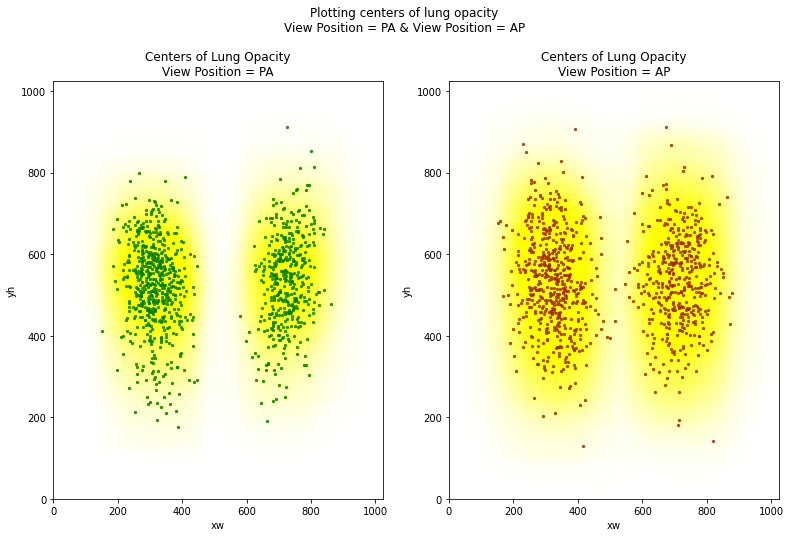

```python
print('Exploring the bounding boxes centers for `ViewPositions` for random sample = 1000')

df1 = bboxes[bboxes['ViewPosition'] == 'PA'].sample(1000)
df2 = bboxes[bboxes['ViewPosition'] == 'AP'].sample(1000)
bboxes_scatter(df1, df2, 'View Position = PA', 'View Position = AP')
```

#### Observations: BodyPartExamined & ViewPosition

Above we saw,

- `BodyPartExamined` is unique for all cases and is CHEST in the training dataset and that was also expected.
- Unique in `Modality` is CR i.e. Computer Radiography
- Overall `ViewPosition` is almost equally distributed in the training dataset but for cases where `Target=1`, most of the view position are `AP`.

[output not shown]

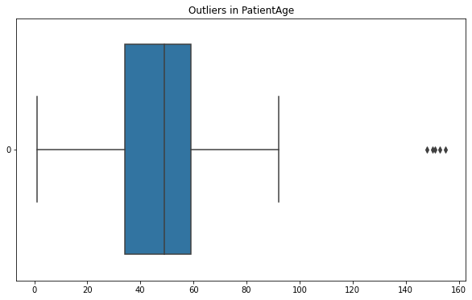

```python
print('Checking outliers in `PatientAge'); print('--'*40)
print('Minimum `PatientAge` in the training dataset: {}'.format(train_class['PatientAge'].min()))
print('Maximum `PatientAge` in the training dataset: {}'.format(train_class['PatientAge'].max()))
print('75th Percentile of `PatientAge` in the training dataset: {}'.format(train_class['PatientAge'].quantile(0.75)))
print('`PatientAge` in upper whisker for box plot: {}'.format(train_class['PatientAge'].quantile(0.75) + (train_class['PatientAge'].quantile(0.75) - train_class['PatientAge'].quantile(0.25))))
print()
fig = plt.figure(figsize = (10, 6))
ax = sns.boxplot(data = train_class['PatientAge'], orient = 'h').set_title('Outliers in PatientAge')
```

We can make use of `pd.clip()` to trim value to a specified lower and upper threshold. So an upper threshold of 100 in PatientAge would mean those outlier values being converted to 100.

```python
print('Using pd.clip to set upper threshold of 100 for age and remove outliers'); print('--'*40)
train_class['PatientAge'] = train_class['PatientAge'].clip(train_class['PatientAge'].min(), 100)
train_class['PatientAge'].describe().astype(int)
```

```
Using pd.clip to set upper threshold of 100 for age and remove outliers
--------------------------------------------------------------------------------
```

```
count    30227
mean        46
std         16
min          1
25%         34
50%         49
75%         59
max        100
Name: PatientAge, dtype: int64
```

```
Get the distribution of `PatientAge` overall and where Target = 1
--------------------------------------------------------------------------------
```

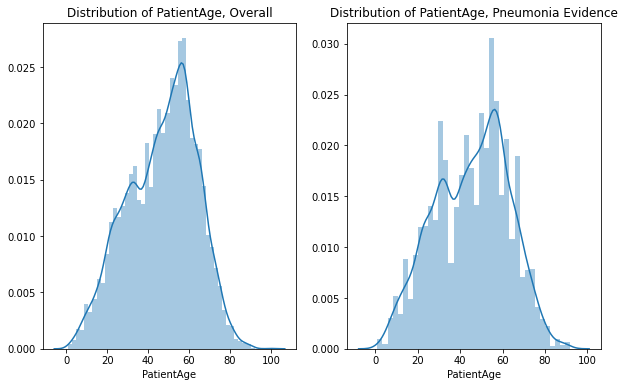

```python
print('Get the distribution of `PatientAge` overall and where Target = 1'); print('--'*40)
fig = plt.figure(figsize = (10, 6))
ax = fig.add_subplot(121)
g = (sns.distplot(train_class['PatientAge'])
    .set_title('Distribution of PatientAge, Overall'))
ax = fig.add_subplot(122)
g = (sns.distplot(train_class.loc[train_class['Target'] == 1, 'PatientAge'])
    .set_title('Distribution of PatientAge, Pneumonia Evidence'))
```

**Using Binning Method for `PatientAge` feature**

We'll make use of a `pd.cut` which is *'Bin values into discrete intervals'*. Use of this method is recommended when need is to segment and sort data values into bins. This function is also useful for going from a continuous variable to a categorical variable. Supports binning into an equal number of bins, or a pre-specified array of bins.

```python
print('Creating Age Binning field', '--'*40)
train_class['AgeBins'] = pd.cut(train_class['PatientAge'], bins = 4, precision = 0, labels = ['<=26', '<=50', '<=75', '<=100'])
train_class['AgeBins'].value_counts()
```

```
Creating Age Binning field --------------------------------------------------------------------------------
```

```
<=75     13318
<=50     12157
<=26      3972
<=100      780
Name: AgeBins, dtype: int64
```

```
Value counts of the age bin field created
--------------------------------------------------------------------------------
```

|  | Counts of Age Bins, Overall | Counts of Age Bins, Target=1 |
| --- | --- | --- |
| <=26 | 3972 | 1478 |
| <=50 | 12157 | 3917 |
| <=75 | 13318 | 3895 |
| <=100 | 780 | 265 |

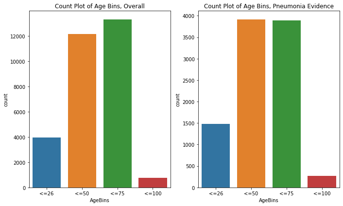

```python
print('Value counts of the age bin field created'); print('--'*40)
display(pd.concat([train_class['AgeBins'].value_counts().sort_index().rename('Counts of Age Bins, Overall'),
                   train_class.loc[train_class['Target'] == 1, 'AgeBins'].value_counts().sort_index().rename('Counts of Age Bins, Target=1')], axis = 1))
print()
f, (ax1, ax2) = plt.subplots(1, 2, figsize = (10, 6))
g = sns.countplot(x = train_class['AgeBins'], ax = ax1).set_title('Count Plot of Age Bins, Overall')
g = sns.countplot(x = train_class.loc[train_class['Target'] == 1, 'AgeBins'], ax = ax2).set_title('Count Plot of Age Bins, Pneumonia Evidence')
plt.tight_layout()
```

```
Exploring the bounding boxes centers for `AgeBins` for random sample = 200
```

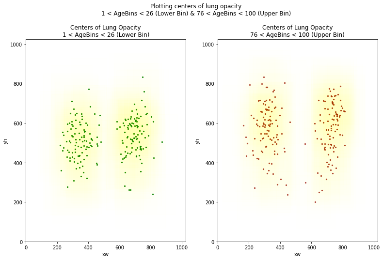

```python
print('Exploring the bounding boxes centers for `AgeBins` for random sample = 200')
# Creating a dataframe with columns for center of the rectangles
bboxes = train_class[train_class['Target'] == 1]
bboxes['xw'] = bboxes['x'] + bboxes['width'] / 2
bboxes['yh'] = bboxes['y'] + bboxes['height'] / 2

df1 = bboxes[bboxes['AgeBins'] == '<=26'].sample(200)
df2 = bboxes[bboxes['AgeBins'] == '<=100'].sample(200)
bboxes_scatter(df1, df2, '1 < AgeBins < 26 (Lower Bin)', '76 < AgeBins < 100 (Upper Bin)')
```

```
Checking distribution of age for those with Pneumonia Evidence, by Gender & Count Plot of Gender
--------------------------------------------------------------------------------
```

|  | % Gender, Overall | % Gender, Target=1 |
| --- | --- | --- |
| F | 0.43 | 0.42 |
| M | 0.57 | 0.58 |

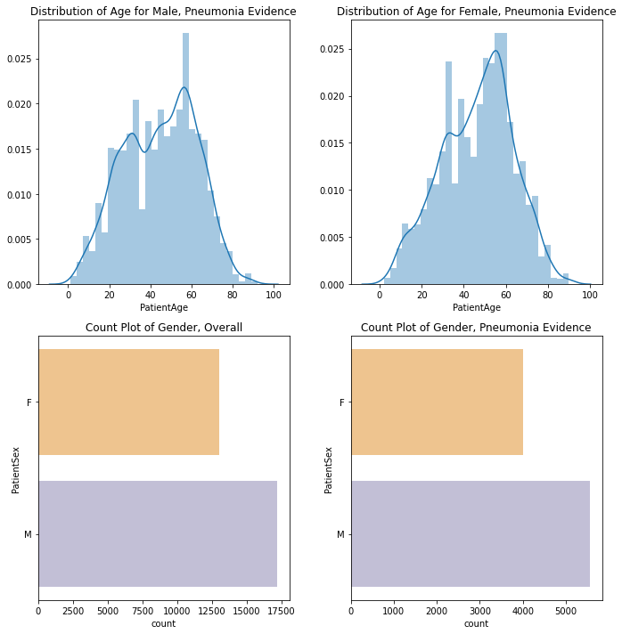

```python
print('Checking distribution of age for those with Pneumonia Evidence, by Gender & Count Plot of Gender'); print('--'*40)
display(pd.concat([train_class['PatientSex'].value_counts(normalize = True).round(2).sort_values().rename('% Gender, Overall'),
                   train_class.loc[(train_class['Target'] == 1), 'PatientSex']
                   .value_counts(normalize = True).round(2).sort_index().rename('% Gender, Target=1')], axis = 1))

f, ((ax1, ax2), (ax3, ax4)) = plt.subplots(2, 2, figsize = (10, 10))
g = sns.distplot(train_class.loc[(train_class['Target'] == 1) & (train_class['PatientSex'] == 'M'), 'PatientAge'], ax = ax1).set_title('Distribution of Age for Male, Pneumonia Evidence')
g = sns.distplot(train_class.loc[(train_class['Target'] == 1) & (train_class['PatientSex'] == 'F'), 'PatientAge'], ax = ax2).set_title('Distribution of Age for Female, Pneumonia Evidence')
g = sns.countplot(y = train_class['PatientSex'], ax = ax3, palette = 'PuOr').set_title('Count Plot of Gender, Overall')
g = sns.countplot(y = train_class.loc[(train_class['Target'] == 1), 'PatientSex'], ax = ax4, palette = 'PuOr').set_title('Count Plot of Gender, Pneumonia Evidence')
plt.tight_layout()
```

```
Exploring the bounding boxes centers for `PatientSex` for random sample = 1000
```

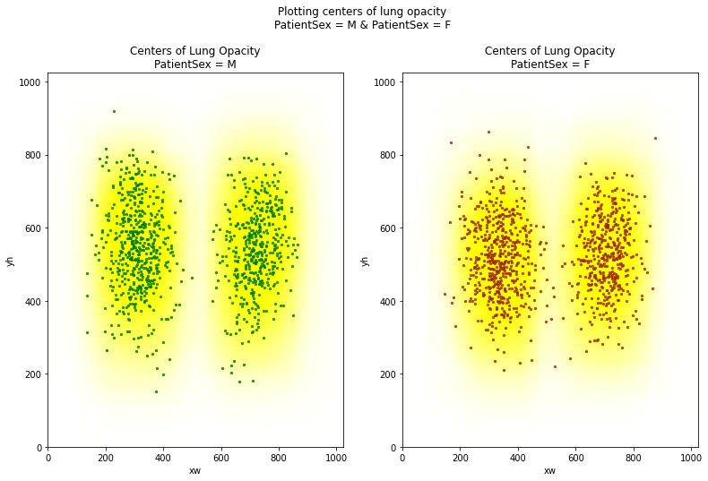

```python
print('Exploring the bounding boxes centers for `PatientSex` for random sample = 1000')
df1 = bboxes[bboxes['PatientSex'] == 'M'].sample(1000)
df2 = bboxes[bboxes['PatientSex'] == 'F'].sample(1000)
bboxes_scatter(df1, df2, 'PatientSex = M', 'PatientSex = F')
```

#### Observations: PatientAge & PatientSex

Above we saw,

> Only `PatientAge`, `PatientSex` and `ViewPosition` are useful features from metadata.

Dropping the other features from `train_class` dataframe and save that as a pickle file

```python
train_class.drop(['BodyPartExamined', 'Modality', 'AgeBins'], inplace = True, axis = 1)
train_class.to_pickle('./output/train_class_features.pkl')
display(train_class.shape, train_class.head())
```

### Check some random samples from training data

Checking some random samples as below:

Now, we will make use of custom module (`eda`) and function (`plot_dicom_images`) already imported earlier to visualize the images.

```
Checking sample for different classes
```

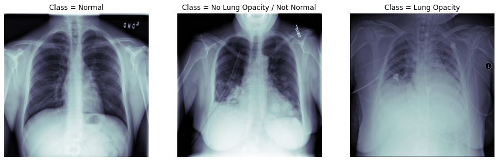

```python
print('Checking sample for different classes')
sample1 = train_class.loc[train_class['class'] == 'Normal'].iloc[0]
sample2 = train_class.loc[train_class['class'] == 'No Lung Opacity / Not Normal'].iloc[0]
sample3 = train_class.loc[train_class['class'] == 'Lung Opacity'].iloc[1]
ds1 = dcm.dcmread(sample1['path'])
ds2 = dcm.dcmread(sample2['path'])
ds3 = dcm.dcmread(sample3['path'])

f, ((ax1, ax2, ax3)) = plt.subplots(1, 3, figsize = (15, 8))
ax1.imshow(ds1.pixel_array, cmap = plt.cm.bone)
ax1.set_title('Class = Normal')
ax1.axis('off')
ax2.imshow(ds2.pixel_array, cmap = plt.cm.bone)
ax2.set_title('Class = No Lung Opacity / Not Normal')
ax2.axis('off')
ax3.imshow(ds3.pixel_array, cmap = plt.cm.bone)
ax3.set_title('Class = Lung Opacity')
ax3.axis('off')
plt.show()
```

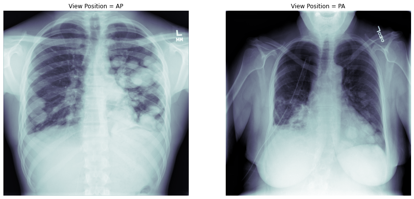

```python
sample4 = train_class.loc[(train_class['ViewPosition'] == 'AP')].iloc[0]
sample5 = train_class.loc[(train_class['ViewPosition'] == 'PA')].iloc[0]
ds4 = dcm.dcmread(sample4['path'])
ds5 = dcm.dcmread(sample5['path'])

f, ((ax1, ax2)) = plt.subplots(1, 2, figsize = (15, 8))
ax1.imshow(ds4.pixel_array, cmap = plt.cm.bone)
ax1.set_title('View Position = AP')
ax1.axis('off')
ax2.imshow(ds5.pixel_array, cmap = plt.cm.bone)
ax2.set_title('View Position = PA')
ax2.axis('off')
plt.show()
```

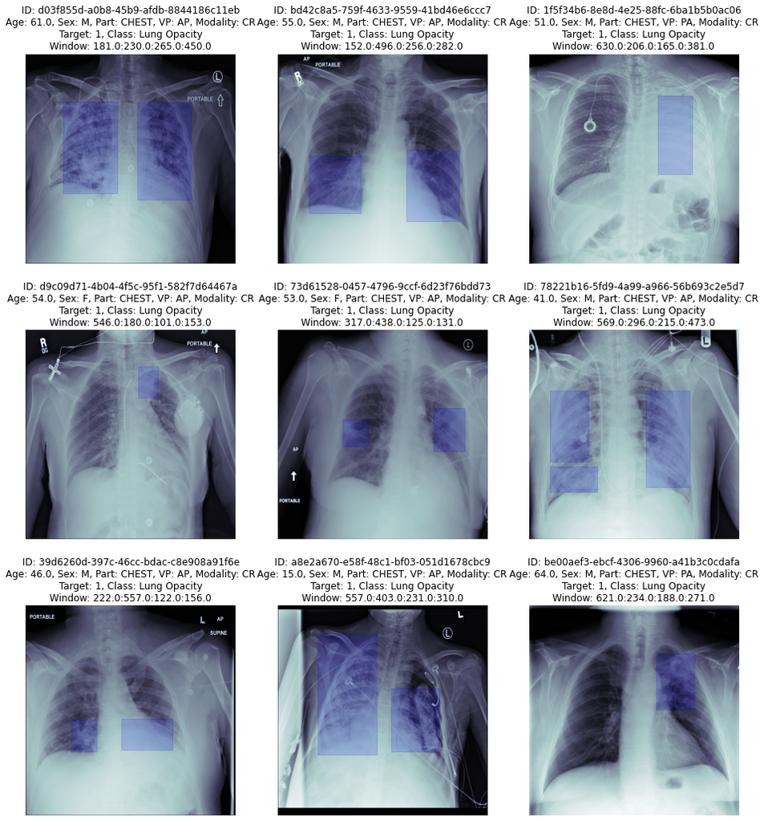

```python
# this function is a part of custom module imported earlier (`eda`)
plot_dicom_images(data = train_class.loc[(train_class['Target'] == 1)].sample(9),
                  df = train_class, img_path = TRAIN_IMAGES)
```

## Data Preparation

### Split into Train & Valid

- Splitting the list of training images in train and valid images
- Random shuffle the list of training images

```python
print('Create training and valid sets. Contains list of filenames'); print('--'*40)
image_fns = os.listdir(TRAIN_IMAGES)
random.shuffle(image_fns)
val_size = round(len(image_fns)/10)
train_size = len(image_fns) - val_size

image_fns_train = image_fns[:train_size]
image_fns_val = image_fns[train_size: (train_size + val_size)]

print('Number of training samples: {}'.format(train_size))
print('Number of valid samples: {}'.format(val_size))
```

```
Create training and valid sets. Contains list of filenames
--------------------------------------------------------------------------------
Number of training samples: 24016
Number of valid samples: 2668
```

### Load Pneumonia Evidence

[*(reference)*](https://www.kaggle.com/jonnedtc/cnn-segmentation-connected-components)

- Dictionary contains pairs per row.
- If there are multiple pneumonia evidence for a patient then the dictionary would contain multiple list tagged to a patient id key. If there's no pneumonia evidence it will have an empty list.

```python
# Reference: https://www.kaggle.com/jonnedtc/cnn-segmentation-connected-components
import numpy as np, pandas as pd
import os, random, pydicom, keras
from skimage.transform import resize
import matplotlib.pyplot as plt
from tensorflow import keras
import tensorflow as tf
import cv2

from skimage import io, measure
from skimage.transform import resize

from matplotlib import pyplot as plt
import matplotlib.patches as patches

DATA_DIR = os.path.join(PATH + 'data/')

if not os.path.exists(DATA_DIR): os.makedirs(DATA_DIR)

def get_pneumonia_evidence(filename):
    pneumonia_evidence = {}
    df = pd.read_csv(DATA_DIR + filename)

    for _, row in df.iterrows():
        fn = row[0]
        loc = row[1:5]
        pneumonia = row[5]
        if pneumonia == 1:
            loc = [int(float(i)) for i in loc]
            if fn in pneumonia_evidence:
                pneumonia_evidence[fn].append(loc)
            else:
                pneumonia_evidence[fn] = [loc]
    return pneumonia_evidence

class generator(keras.utils.Sequence):

    def __init__(self, folder, fns, pneumonia_evidence = None,
                 batch_size = 32, image_size = 256,
                 shuffle = True, augment = False, predict = False):
        self.folder = folder
        self.fns = fns
        self.pneumonia_evidence = pneumonia_evidence
        self.batch_size = batch_size
        self.image_size = image_size
        self.shuffle = shuffle
        self.augment = augment
        self.predict = predict
        self.on_epoch_end()

    def __load__(self, fn):
        img = pydicom.dcmread(os.path.join(self.folder, fn)).pixel_array
        msk = np.zeros(img.shape)
        fn = fn.split('.')[0]
        if fn in self.pneumonia_evidence:
            for loc in self.pneumonia_evidence[fn]:
                x, y, w, h = loc
                msk[y:y+h, x:x+w] = 1
        img = resize(img, (self.image_size, self.image_size), mode = 'reflect')
        msk = resize(msk, (self.image_size, self.image_size), mode = 'reflect') > 0.5
        if self.augment and random.random() > 0.5:
            img = np.fliplr(img)
            msk = np.fliplr(msk)
        img = np.expand_dims(img, -1)
        msk = np.expand_dims(msk, -1)
        return img, msk

    def __loadpredict__(self, fn):
        img = pydicom.dcmread(os.path.join(self.folder, fn)).pixel_array
        img = resize(img, (self.image_size, self.image_size), mode = 'reflect')
        img = np.expand_dims(img, -1)
        return img

    def __getitem__(self, index):
        fns = self.fns[index*self.batch_size:(index+1)*self.batch_size]

        if self.predict:
            imgs = [self.__loadpredict__(fn) for fn in fns]
            imgs = np.array(imgs)
            return imgs, fns

        else:
            items = [self.__load__(fn) for fn in fns]
            imgs, msks = zip(*items)
            imgs = np.array(imgs)
            msks = np.array(msks)
            return imgs, msks

    def on_epoch_end(self):
        if self.shuffle:
            random.shuffle(self.fns)

    def __len__(self):
        if self.predict:
            return int(np.ceil(len(self.fns)/self.batch_size))
        else:
            return int(len(self.fns)/self.batch_size)

# define iou or jaccard loss function
def iou_loss(y_true, y_pred):
    y_true = tf.reshape(y_true, [-1])
    y_pred = tf.reshape(y_pred, [-1])
    intersection = tf.reduce_sum(y_true * y_pred)
    score = (intersection + 1.) / (tf.reduce_sum(y_true) + tf.reduce_sum(y_pred) - intersection + 1.)
    return 1 - score

# combine bce loss and iou loss
def iou_bce_loss(y_true, y_pred):
    return 0.5 * keras.losses.binary_crossentropy(y_true, y_pred) + 0.5 * iou_loss(y_true, y_pred)

# mean iou as a metric
def mean_iou(y_true, y_pred):
    y_pred = tf.round(y_pred)
    intersect = tf.reduce_sum(y_true * y_pred, axis=[1, 2, 3])
    union = tf.reduce_sum(y_true, axis=[1, 2, 3]) + tf.reduce_sum(y_pred, axis=[1, 2, 3])
    smooth = tf.ones(tf.shape(intersect))
    return tf.reduce_mean((intersect + smooth) / (union - intersect + smooth))

# create network and compiler
# model = create_network(input_size = 256, channels = 32, n_blocks = 2, depth = 4)
# model.compile(optimizer = 'adam',
#               loss = iou_bce_loss,
#               metrics = ['accuracy', mean_iou])

# cosine learning rate annealing
def cosine_annealing(x):
    lr = 0.001
    epochs = 25
    return lr*(np.cos(np.pi*x/epochs)+1.)/2

# Function to plot masks that are generated using `generator` function above
def plot_masks(df, path, image_fns, pneumonia_evidence):
  sample_patient_id = random.choice(list(df.loc[(df['Target'] == 1), 'patientId']))
  sample_fn = sample_patient_id + '.dcm'
  sample_details = df.loc[df['patientId'] == sample_patient_id]

  g = generator(path, image_fns, pneumonia_evidence)
  img, msk = g.__load__(sample_fn)
  fig, (ax1, ax2, ax3) = plt.subplots(1, 3, figsize = (15, 6))

  _ = ax1.imshow(img[:,:,0], cmap = plt.cm.bone); _ = ax1.axis('off')
  _ = ax2.imshow(msk[:,:,0]); _ = ax2.axis('off')
  _ = ax3.imshow(cv2.bitwise_and(img, img, mask = msk.astype(np.uint8)),
                cmap = plt.cm.bone); _ = ax3.axis('off')

  _ = ax1.set_title('{}\nAge: {}, Gender: {}, VP: {}\nSample Image'.format(sample_patient_id,
                list(sample_details['PatientAge'].unique())[0],
                list(sample_details['PatientSex'].unique())[0],
                list(sample_details['ViewPosition'].unique())[0]))
  _ = ax2.set_title('{}\nAge: {}, Gender: {}, VP: {}\nMask for Sample Image'.format(sample_patient_id,
                list(sample_details['PatientAge'].unique())[0],
                list(sample_details['PatientSex'].unique())[0],
                list(sample_details['ViewPosition'].unique())[0]))
  _ = ax3.set_title('{}\nAge: {}, Gender: {}, VP: {}\nMask overlay over Image'.format(sample_patient_id,
                list(sample_details['PatientAge'].unique())[0],
                list(sample_details['PatientSex'].unique())[0],
                list(sample_details['ViewPosition'].unique())[0]))
  plt.subplots_adjust(top = 0.4)
  plt.tight_layout()
```

```python
print('Load pneumonia evidence dictionary from `stage_2_train_labels.csv`'); print('--'*40)
pneumonia_evidence = get_pneumonia_evidence(filename = 'stage_2_train_labels.csv')
```

```
Load pneumonia evidence dictionary from `stage_2_train_labels.csv`
--------------------------------------------------------------------------------
```

```python
list(pneumonia_evidence.keys())[0], list(pneumonia_evidence.values())[0]
```

```
('00436515-870c-4b36-a041-de91049b9ab4',
 [[264, 152, 213, 379], [562, 152, 256, 453]])
```

```
Plot Masks generated using `generator` function, randomly
--------------------------------------------------------------------------------
GROUND TRUTH --------------------------------------------------
```

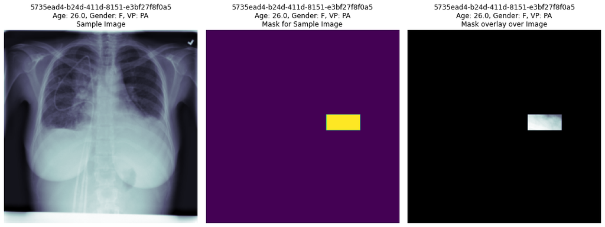

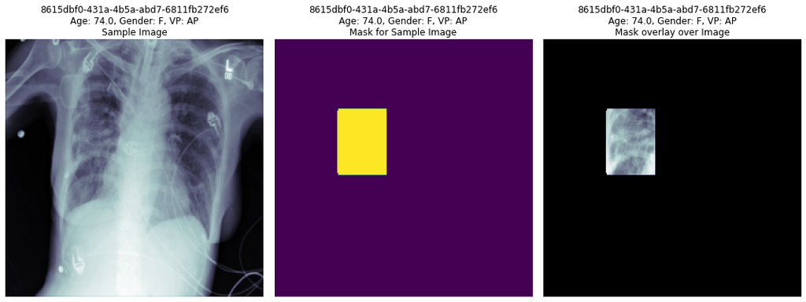

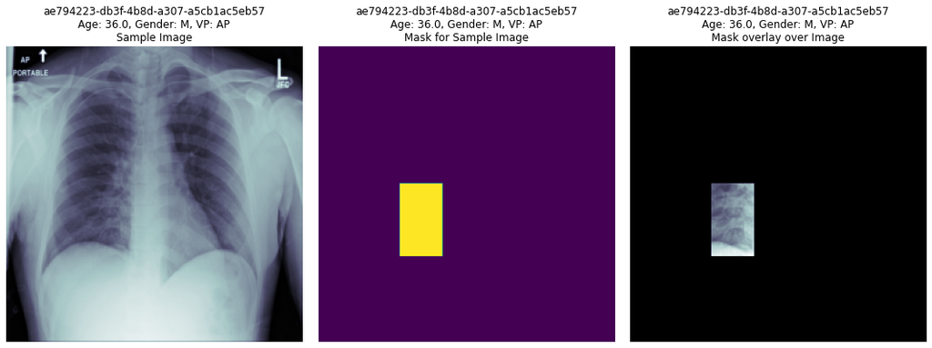

```python
print('Plot Masks generated using `generator` function, randomly'); print('--'*40)
print('GROUND TRUTH', '--'*25)
plot_masks(train_class, TRAIN_IMAGES, image_fns, pneumonia_evidence)
plot_masks(train_class, TRAIN_IMAGES, image_fns, pneumonia_evidence)
plot_masks(train_class, TRAIN_IMAGES, image_fns, pneumonia_evidence)
```

```python
# IMPORT PACKAGES
import warnings; warnings.filterwarnings('ignore')
import pandas as pd, numpy as np
import matplotlib.pyplot as plt
import os, random, csv
import seaborn as sns
from glob import glob
from tqdm import tqdm
%matplotlib inline

# MODEL METRICS
from mlxtend.plotting import plot_confusion_matrix
from sklearn.model_selection import train_test_split

# SET VARIABLES
PATH = '/content/drive/My Drive/Final_Project/'
os.chdir(PATH)

DATA_DIR = os.path.join(PATH + 'data/')
TRAIN_IMAGES = os.path.join(DATA_DIR + 'stage_2_train_images/')
TEST_IMAGES = os.path.join(DATA_DIR + 'stage_2_test_images/')
OUTPUT_DIR = os.path.join(PATH + 'output/')
MODEL_WEIGHTS = os.path.join(PATH + 'model_weights/')
TRAIN_IMAGES_DIR = os.path.join(DATA_DIR + 'stage_2_train_images_png/')
if not os.path.exists(TRAIN_IMAGES_DIR): os.makedirs(TRAIN_IMAGES_DIR)
if not os.path.exists(MODEL_WEIGHTS): os.makedirs(MODEL_WEIGHTS)

# CUSTOM MODULE
from module.classify import *

# SET RANDOM SEED
random_state = 2020
random.seed(random_state)
np.random.seed(random_state)

# USE GPU FOR MODEL TRAINING
config = tf.compat.v1.ConfigProto(log_device_placement = True, allow_soft_placement = True)
config.gpu_options.allow_growth = True
session = tf.compat.v1.Session(config = config)
list_gpu = tf.config.experimental.list_physical_devices(device_type = 'GPU')
if len(list_gpu)==1: strategy = tf.distribute.OneDeviceStrategy(device='/gpu:0')
else: strategy = tf.distribute.MirroredStrategy()
print('Num GPUs Available: ', len(list_gpu))
tf.config.optimizer.set_experimental_options({'auto_mixed_precision': True})
print('Mixed precision enabled')
```

```
Device mapping:
/job:localhost/replica:0/task:0/device:XLA_CPU:0 -> device: XLA_CPU device
/job:localhost/replica:0/task:0/device:XLA_GPU:0 -> device: XLA_GPU device
/job:localhost/replica:0/task:0/device:GPU:0 -> device: 0, name: Tesla T4, pci bus id: 0000:00:04.0, compute capability: 7.5

Num GPUs Available:  1
Mixed precision enabled
```

```python
# Read `train_class_features.pkl` file, saved as EDA & Data Prep Module
train_class = pd.read_pickle('/content/drive/My Drive/Final_Project/output/train_feature_engineered.pkl')
display(train_class.shape, train_class.head())
```

```
(30227, 14)
```

|  | patientId | x | y | width | height | Target | number_of_boxes | class | path | PatientSex | PatientAge | BodyPartExamined | ViewPosition | Modality |
| --- | --- | --- | --- | --- | --- | --- | --- | --- | --- | --- | --- | --- | --- | --- |
| 0 | 0004cfab-14fd-4e49-80ba-63a80b6bddd6 | NaN | NaN | NaN | NaN | 0 | 1 | No Lung Opacity / Not Normal | /content/drive/My Drive/Final_Project/data/sta... | F | 51.0 | CHEST | PA | CR |
| 1 | 00313ee0-9eaa-42f4-b0ab-c148ed3241cd | NaN | NaN | NaN | NaN | 0 | 1 | No Lung Opacity / Not Normal | /content/drive/My Drive/Final_Project/data/sta... | F | 48.0 | CHEST | PA | CR |
| 2 | 00322d4d-1c29-4943-afc9-b6754be640eb | NaN | NaN | NaN | NaN | 0 | 1 | No Lung Opacity / Not Normal | /content/drive/My Drive/Final_Project/data/sta... | M | 19.0 | CHEST | AP | CR |
| 3 | 003d8fa0-6bf1-40ed-b54c-ac657f8495c5 | NaN | NaN | NaN | NaN | 0 | 1 | Normal | /content/drive/My Drive/Final_Project/data/sta... | M | 28.0 | CHEST | PA | CR |
| 4 | 00436515-870c-4b36-a041-de91049b9ab4 | 264.0 | 152.0 | 213.0 | 379.0 | 1 | 2 | Lung Opacity | /content/drive/My Drive/Final_Project/data/sta... | F | 32.0 | CHEST | AP | CR |

```python
# A dataframe with paths, classes and targets
print('Prepare a dataframe with paths, classes and targets'); print('--'*40)
path_class_target = train_class[['patientId', 'path', 'class', 'Target']].copy(deep = True)
path_class_target['path'] = (path_class_target['path']
                             .str.replace('stage_2_train_images', 'stage_2_train_images_png')
                             .str.replace('.dcm', '.png'))
path_class_target.drop_duplicates(inplace = True)
display(path_class_target.shape, path_class_target.nunique())
print('\nDistribution of target and classes')
display(path_class_target['Target'].value_counts())
print()
display(path_class_target['class'].value_counts())
```

```
Prepare a dataframe with paths, classes and targets
--------------------------------------------------------------------------------
```

```
(26684, 4)
```

```
patientId    26684
path         26684
class            3
Target           2
dtype: int64
```

```
Distribution of target and classes
```

```
0    20672
1     6012
Name: Target, dtype: int64
```

```
No Lung Opacity / Not Normal    11821
Normal                           8851
Lung Opacity                     6012
Name: class, dtype: int64
```

```python
# Run only if you haven't converted to png images yet
print('Convert dicom to png images'); print('--'*40)

image_lists = [f for f in os.listdir(TRAIN_IMAGES)]
for f in tqdm_notebook(image_lists):
    ds = dcm.read_file(TRAIN_IMAGES + f)
    img = ds.pixel_array
    cv2.imwrite(TRAIN_IMAGES_DIR + f.replace('.dcm','.png'), img)
```

```
Convert dicom to png images
--------------------------------------------------------------------------------
```

```python
# Split the data in train, valid and test sets
print('Split the data in train, valid and test sets'); print('--'*40)

image_list = list(path_class_target['path'])
random.shuffle(image_list)
val_size = round(len(image_list)/10)
test_size = round(len(image_list)/10)
train_size = len(image_list)-test_size-val_size

X_train = image_list[:train_size]
X_valid = image_list[train_size:(train_size + val_size)]
X_test = image_list[(train_size + val_size):]
```

```
Split the data in train, valid and test sets
--------------------------------------------------------------------------------
```

```python
print('Create Training, Validation and Test Dataframe with Path and Target'); print('--'*40)

df_train = (path_class_target.merge(pd.Series(X_train, name = 'path'),
                                    on = 'path',
                                    how = 'right')
          .drop(['class'], axis = 1))

df_valid = (path_class_target.merge(pd.Series(X_valid, name = 'path'),
                                    on = 'path',
                                    how = 'right')
          .drop(['class'], axis = 1))

df_test = (path_class_target.merge(pd.Series(X_test, name = 'path'),
                                    on = 'path',
                                    how = 'right')
          .drop(['class'], axis = 1))

print('Shape of the dataframes:\nTRAIN:{}\nVALID:{}\nTEST:{}'.format(df_train.shape, df_valid.shape, df_test.shape))
```

```
Create Training, Validation and Test Dataframe with Path and Target
--------------------------------------------------------------------------------
Shape of the dataframes:
TRAIN:(21348, 3)
VALID:(2668, 3)
TEST:(2668, 3)
```

```python
print('Training, Validation and Test set is ~equally distributed on target'); print('--'*40)
print('Distribution of target in the training set:');
display(pd.Series(df_train['Target']).value_counts(normalize = True).round(2))
print('\nDistribution of target in the validation set:');
display(pd.Series(df_valid['Target']).value_counts(normalize = True).round(2))
print('\nDistribution of target in the test set:');
display(pd.Series(df_test['Target']).value_counts(normalize = True).round(2))
```

```
Training, Validation and Test set is ~equally distributed on target
--------------------------------------------------------------------------------
Distribution of target in the training set:
```

```
0    0.78
1    0.22
Name: Target, dtype: float64
```

```
Distribution of target in the validation set:
```

```
0    0.78
1    0.22
Name: Target, dtype: float64
```

```
Distribution of target in the test set:
```

```
0    0.77
1    0.23
Name: Target, dtype: float64
```

```python
print('Save the train, valid and test dataframes for future use');print('--'*40)
df_train.to_pickle(OUTPUT_DIR + 'train_data.pkl')
df_valid.to_pickle(OUTPUT_DIR + 'valid_data.pkl')
df_test.to_pickle(OUTPUT_DIR + 'test_data.pkl')
```

```
Save the train, valid and test dataframes for future use
--------------------------------------------------------------------------------
```

```python
# Model Parameters
BATCH_SIZE = 32
IMAGE_SIZE = 224
EPOCH = 10
LEARNING_RATE = 1e-4
MONITOR = 'val_loss'
MODE = 'min'
VERBOSE = 1
FACTOR = 0.1
PATIENCE = 5
COOLDOWN = 5
BEST_MODEL = 'best_densenet.h5'
FINAL_MODEL = 'best_densenet_final.h5'
LOG_FILE = 'logs.csv'
LOSS = 'binary_crossentropy'
METRICS = ['accuracy', average_precision, f1_score]
```

```python
df_train['Target'] = df_train['Target'].astype(str);
df_valid['Target'] = df_valid['Target'].astype(str);
df_test['Target'] = df_test['Target'].astype(str)
```

```python
print('Create generators for training, validation and test dataframes'); print('--'*40)
generators = DataGenerators(df_train, df_valid, df_test,
                            batch_size = BATCH_SIZE,
                            path = TRAIN_IMAGES_DIR,
                            img_size = (IMAGE_SIZE, IMAGE_SIZE),
                            class_mode = 'binary',
                            random_state = random_state)
```

```
Create generators for training, validation and test dataframes
--------------------------------------------------------------------------------
Train Generator Created ----------------------------------------
Found 21348 validated image filenames belonging to 2 classes.
Validation Generator Created ----------------------------------------
Found 2668 validated image filenames belonging to 2 classes.
Test Generator Created ----------------------------------------
Found 2668 validated image filenames belonging to 2 classes.
```

```python
def build_model():
    print('Create a `DenseNet121` model'); print('--'*40)
    input_shape = (IMAGE_SIZE, IMAGE_SIZE, 3)
    inputs = Input(shape = input_shape)
    initializer = tf.keras.initializers.GlorotNormal()

    base_model = DenseNet121(include_top = False, input_tensor = inputs, weights ='imagenet')

    densenet = Model(inputs = inputs, outputs = base_model.layers[-1].output, name = 'DenseNet121')

    model = Sequential(name = 'DenseNet121')
    model.add(densenet)
    model.add(GlobalAveragePooling2D())
    model.add(Dropout(0.4))
    model.add(Dense(1, activation = 'sigmoid', kernel_initializer = initializer))
    model.summary()
    return model

def callbacks():
    lrscheduler = ReduceLROnPlateau(monitor = MONITOR, factor = FACTOR,
                                    patience = PATIENCE, verbose = VERBOSE,
                                    mode = MODE, cooldown = COOLDOWN)

    model.compile(optimizer = Adam(lr = LEARNING_RATE), loss = LOSS, metrics = METRICS)

    cp = ModelCheckpoint(filepath = MODEL_WEIGHTS + BEST_MODEL, monitor = MONITOR,
                         verbose = VERBOSE, save_best_only = True, mode = MODE)

    if os.path.exists(MODEL_WEIGHTS + LOG_FILE): os.remove(MODEL_WEIGHTS + LOG_FILE)
    csv_logger = CSVLogger(MODEL_WEIGHTS + LOG_FILE, append = True)

    callbacks = [cp, csv_logger, lrscheduler]
    return callbacks
```

```python
print('Lets fit the model.....')
K.clear_session()
with strategy.scope():
    model = build_model()
    callbacks = callbacks()
    train_generator = generators.train_generator
    validation_generator = generators.valid_generator
    test_generator = generators.test_generator
    history = model.fit_generator(generator = train_generator,
                                  steps_per_epoch = generators.step_size_train,
                                  epochs = EPOCH, verbose = VERBOSE,
                                  callbacks = callbacks,
                                  validation_data = validation_generator,
                                  validation_steps = generators.step_size_valid)
    print('Save the final weights'); print('--'*40)
    model.save(MODEL_WEIGHTS + FINAL_MODEL)
```

```
Lets fit the model.....
Create a `DenseNet121` model
--------------------------------------------------------------------------------
Downloading data from https://storage.googleapis.com/tensorflow/keras-applications/densenet/densenet121_weights_tf_dim_ordering_tf_kernels_notop.h5
Model: "DenseNet121"
_________________________________________________________________
Layer (type)                 Output Shape              Param #
=================================================================
DenseNet121 (Model)          (None, 7, 7, 1024)        7037504
_________________________________________________________________
global_average_pooling2d (Gl (None, 1024)              0
_________________________________________________________________
dropout (Dropout)            (None, 1024)              0
_________________________________________________________________
dense (Dense)                (None, 1)                 1025
=================================================================
Total params: 7,038,529
Trainable params: 6,954,881
Non-trainable params: 83,648
_________________________________________________________________
Epoch 00001: val_loss improved from inf to 0.45740, saving model to /content/drive/My Drive/Final_Project/model_weights/best_densenet.h5
Epoch 00002: val_loss improved from 0.45740 to 0.36086, saving model to /content/drive/My Drive/Final_Project/model_weights/best_densenet.h5
Epoch 00003: val_loss did not improve from 0.36086
Epoch 00004: val_loss improved from 0.36086 to 0.33994, saving model to /content/drive/My Drive/Final_Project/model_weights/best_densenet.h5
Epoch 00005: val_loss did not improve from 0.33994
Epoch 00006: val_loss did not improve from 0.33994
Epoch 00007: val_loss did not improve from 0.33994
Epoch 00008: val_loss improved from 0.33994 to 0.33866, saving model to /content/drive/My Drive/Final_Project/model_weights/best_densenet.h5
Epoch 00009: val_loss did not improve from 0.33866
Epoch 00010: val_loss improved from 0.33866 to 0.33478, saving model to /content/drive/My Drive/Final_Project/model_weights/best_densenet.h5
Save the final weights
--------------------------------------------------------------------------------
```

```python
print('Reloading model weights and lets evaluate on validation set'); print('--'*40)
model.load_weights(MODEL_WEIGHTS + BEST_MODEL)
```

```
Reloading model weights and lets evaluate on validation set
--------------------------------------------------------------------------------
```

```python
print('Evaluate the model on validation data'); print('--'*40)

loss, accuracy, ap, f1 = model.evaluate_generator(generator = validation_generator,
                                          steps = generators.step_size_valid)
print(f'Loss: {round(loss, 3)}, Accuracy: {round(float(accuracy), 3)}, AP: {round(float(ap), 3)}, F1 Score: {round(float(f1), 3)}')
```

```
Evaluate the model on validation data
--------------------------------------------------------------------------------
Loss: 0.335, Accuracy: 0.851, AP: 0.689, F1 Score: 0.628
```

```python
print('Predict on the validation data'); print('--'*40)
validation_generator.reset()
valid_pred_roc = model.predict_generator(generator = validation_generator,
                                         steps = generators.step_size_valid,
                                         verbose = 1)
valid_pred = []
for i in valid_pred_roc:
    if i >= 0.5: valid_pred.append(1)
    else: valid_pred.append(0)
y_valid = df_valid['Target'].astype(int).values
```

```
Predict on the validation data
--------------------------------------------------------------------------------
```

```python
print('Predict on the test data'); print('--'*40)
test_generator.reset()
test_pred_roc = model.predict_generator(generator = test_generator,
                                        steps = generators.step_size_test,
                                        verbose = 1)
test_pred = []
for i in test_pred_roc:
    if i >= 0.5: test_pred.append(1)
    else: test_pred.append(0)
y_test = df_test['Target'].astype(int).values
```

```
Predict on the test data
--------------------------------------------------------------------------------
```

```python
display(pd.Series(y_valid).value_counts(), pd.Series(y_test).value_counts())
```

```
0    2071
1     597
dtype: int64
```

```
0    2042
1     626
dtype: int64
```

```
ROC Curve for the validation data
--------------------------------------------------------------------------------
AUC: 0.890
```

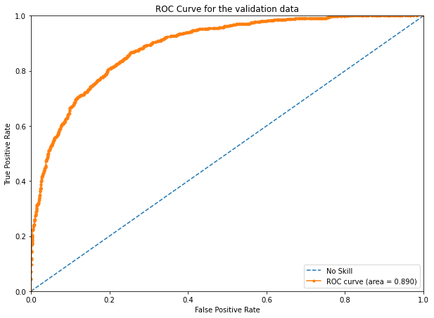

```python
print('ROC Curve for the validation data'); print('--'*40)

roc_auc_valid = roc_auc_score(y_valid, np.array(valid_pred_roc).reshape(-1))
print('AUC: {:0.3f}'.format(roc_auc_valid))

fig = plt.figure(figsize = (10, 7.2))
fpr, tpr, thresholds = roc_curve(y_valid, np.array(valid_pred_roc).reshape(-1))
plt.title('ROC Curve for the validation data')
plt.ylabel('True Positive Rate')
plt.xlabel('False Positive Rate')
plt.axis([0, 1, 0, 1])
plt.plot([0, 1], [0, 1], linestyle = '--', label = 'No Skill')
plt.plot(fpr, tpr, marker = '.', label = 'ROC curve (area = %0.3f)' % roc_auc_valid)
plt.legend(loc = 'lower right')
plt.show()
```

```
ROC Curve for the test data
--------------------------------------------------------------------------------
AUC: 0.894
```

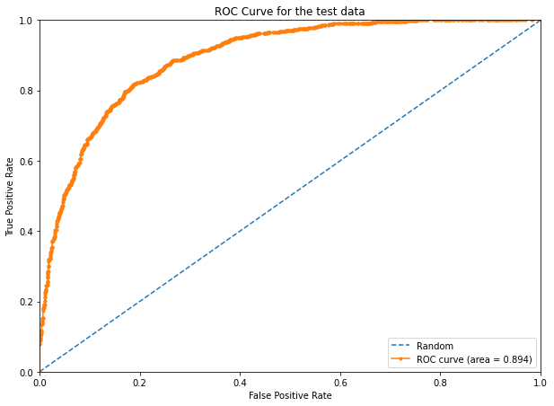

```python
print('ROC Curve for the test data'); print('--'*40)

roc_auc_test = roc_auc_score(y_test, np.array(test_pred_roc).reshape(-1))
print('AUC: {:0.3f}'.format(roc_auc_test))

fig = plt.figure(figsize = (10, 7.2))
fpr, tpr, thresholds = roc_curve(y_test, np.array(test_pred_roc).reshape(-1))
plt.title('ROC Curve for the test data')
plt.ylabel('True Positive Rate')
plt.xlabel('False Positive Rate')
plt.axis([0, 1, 0, 1])
plt.plot([0, 1], [0, 1], linestyle = '--', label = 'Random')
plt.plot(fpr, tpr, marker = '.', label = 'ROC curve (area = %0.3f)' % roc_auc_test)
plt.legend(loc = 'lower right')
plt.show()
```

```
Confusion Matrix on the test data
--------------------------------------------------------------------------------
```

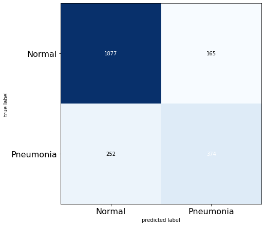

```python
print('Confusion Matrix on the test data'); print('--'*40)
cm = confusion_matrix(y_test, test_pred)
plot_confusion_matrix(cm, figsize = (10, 7.2), cmap = plt.cm.Blues)
plt.xticks(range(2), ['Normal', 'Pneumonia'], fontsize = 16)
plt.yticks(range(2), ['Normal', 'Pneumonia'], fontsize = 16)
plt.show()
```

```python
print('Classification Report on the test data'); print('--'*60)
print(classification_report(y_test, test_pred, target_names = ['Normal', 'Pneumonia']))
```

```
Classification Report on the test data
------------------------------------------------------------------------------------------------------------------------
              precision    recall  f1-score   support

      Normal       0.88      0.92      0.90      2042
   Pneumonia       0.69      0.60      0.64       626

    accuracy                           0.84      2668
   macro avg       0.79      0.76      0.77      2668
weighted avg       0.84      0.84      0.84      2668
```

```python
# Model Parameters
BATCH_SIZE = 32
IMAGE_SIZE = 224
EPOCH = 10
LEARNING_RATE = 1e-3
MONITOR = 'val_loss'
MODE = 'min'
VERBOSE = 1
FACTOR = 0.1
PATIENCE = 5
COOLDOWN = 5
BEST_MODEL = 'best_chexnet.h5'
FINAL_MODEL = 'best_chexnet_final.h5'
LOG_FILE = 'logs_chexnet.csv'
LOSS = 'binary_crossentropy'
METRICS = ['accuracy', average_precision, f1_score]
```

```python
print('Create generators for training, validation and test dataframes'); print('--'*40)
generators = DataGenerators(df_train, df_valid, df_test,
                            batch_size = BATCH_SIZE,
                            path = TRAIN_IMAGES_DIR,
                            img_size = (IMAGE_SIZE, IMAGE_SIZE),
                            class_mode = 'binary',
                            random_state = random_state)
```

```
Create generators for training, validation and test dataframes
--------------------------------------------------------------------------------
Train Generator Created ----------------------------------------
Found 21348 validated image filenames belonging to 2 classes.
Validation Generator Created ----------------------------------------
Found 2668 validated image filenames belonging to 2 classes.
Test Generator Created ----------------------------------------
Found 2668 validated image filenames belonging to 2 classes.
```

```python
def build_model():
    print('Create a `CheXNet-like` model using pre-trained weights'); print('--'*40)
    input_shape = (IMAGE_SIZE, IMAGE_SIZE, 3)
    inputs = Input(shape = input_shape)
    initializer = tf.keras.initializers.GlorotNormal()

    base_model = DenseNet121(include_top = True, input_tensor = inputs, weights = MODEL_WEIGHTS + 'CheXNet weights.h5', classes = 14)

    densenet = Model(inputs = inputs, outputs = base_model.layers[-2].output, name = 'CheXNet-like')

    model = Sequential(name = 'CheXNet-like')
    model.add(densenet)
    model.add(Dropout(0.2))
    model.add(Dense(1, activation = 'sigmoid', kernel_initializer = initializer))
    model.summary()
    return model

def callbacks():
    lrscheduler = ReduceLROnPlateau(monitor = MONITOR, factor = FACTOR,
                                    patience = PATIENCE, verbose = VERBOSE,
                                    mode = MODE, cooldown = COOLDOWN)

    model.compile(optimizer = Adam(lr = LEARNING_RATE), loss = LOSS, metrics = METRICS)

    cp = ModelCheckpoint(filepath = MODEL_WEIGHTS + BEST_MODEL, monitor = MONITOR,
                         verbose = VERBOSE, save_best_only = True, mode = MODE)

    if os.path.exists(MODEL_WEIGHTS + LOG_FILE): os.remove(MODEL_WEIGHTS + LOG_FILE)
    csv_logger = CSVLogger(MODEL_WEIGHTS + LOG_FILE, append = True)

    callbacks = [cp, csv_logger, lrscheduler]
    return callbacks
```

```python
print('Lets fit the model.....')
K.clear_session()
with strategy.scope():
    model = build_model()
    callbacks = callbacks()
    train_generator = generators.train_generator
    validation_generator = generators.valid_generator
    test_generator = generators.test_generator
    history = model.fit_generator(generator = train_generator,
                                  steps_per_epoch = generators.step_size_train,
                                  epochs = EPOCH, verbose = VERBOSE,
                                  callbacks = callbacks,
                                  validation_data = validation_generator,
                                  validation_steps = generators.step_size_valid)
    print('Save the final weights'); print('--'*40)
    model.save(MODEL_WEIGHTS + FINAL_MODEL)
```

```
Lets fit the model.....
Create a `CheXNet-like` model using pre-trained weights
--------------------------------------------------------------------------------
```

[output not shown]